# A2: NeuralNetwork Class

# Table of Contents

## Requirements

In this assignment, you will complete the implementation of the `NeuralNetwork` class, starting with the code included in the `04b` lecture notes. Your implementation must

1. Allow any number of hidden layers, including no hidden layers specified by an empty list as `[]`. Don't forget this case.
2. Define `_forward(self, X)` and `_gradients(self, X, T` functions. `_forward` must return the output of the network, `Y`, in standardized form and create `self.Zs` as a list consisting of the input `X` and the outputs of all hidden layers. `_gradients` must return the gradients of the mean square error with respect to the weights in each layer.
3. Your `train` function must standardize `X` and `T` and save the standardization parameters (means and stds) in member variables. It must append to `self.rmse_trace` the RMSE value for each epoch. Initialize this list to be `[]` in the constructor to allow multiple calls to `train` to continue to append to the same `rmse_trace` list.
4. Your `use` function must standardize `X` and unstandardize the output.

See the following examples for more details.

Then apply your `NeuralNetwork` class to the problem of predicting the value of houses in Boston as described below.

## Code for `NeuralNetwork` Class

```python
import numpy as np
import pandas as pd
import matplotlib.pyplot as plt
%matplotlib inline
import IPython.display as ipd  # for display and clear_output
import time
```

```python
class NeuralNetwork():
    """
    A Neural Network class consisting methods to create a neural network. Written for non-linear regression problems.

    :param n_inputs: int
                     Number of variable columns in the dataset (excluding output varibales).
                     Represents number of predictors in the model.
    :param n_hiddens_each_layer: list of int
                                 Number of units in each hidden layers. Each element of the list represents
                                 to one hidden layer.
    :param n_outputs: int
                      Number of output variables to predict.
    :param n_epochs: int|
                     Number of epochs to run. Default is None. Updates from the train() function.
    :param rho: float
                Learning rate of the neural network. Default is None. Updates from the train() function.

    :param rmse_trace: list of floats
                       An auto-updated list generated while training the model. Holds all rmse values while training.
    :param X_means : 1D numpy array
                     Mean value of input variables.
    :param X_stds : 1D numpy array
                    Standard deviation of input variables.
    :param T_means : 1D numpy array
                     Mean value of output variables.
    :param T_stds : 1D numpy array
                    Standard deviation of output variables.

    ---------------------
    Methods:

    rmse_score() : Calculates RMSE score.
    _add_ones() : Adds a column of 1 in the begininning of an array. Used to add bias to data.
    _generate_weights() : Generates weights for hidden layers of the neural network based on class inputs.
    _forward() : Performs the forward propagation steps.
    _gradients() : Performs backward propagation to generate gradients.
    train() : Trains the neural network with input parameters and updates weights.
    use() : Predicts output variable using the trained model.

    """

    def __init__(self, n_inputs, n_hiddens_each_layer, n_outputs):
        """
        Generates a neural network with a given structure. Holds various parameters of the
        neural network.

        :param n_inputs: int
                         Number of variable columns in the dataset (excluding output varibales).
                         Represents number of predictors in the model.
        :param n_hiddens_each_layer: list of int
                                     Number of units in each hidden layers. Each element of the list represents one hidden layer.
        :param n_outputs: int
                          Number of output variables to predict.

        :return: A Neural netwrk object.
        """
        self.n_inputs = n_inputs
        self.n_hiddens_each_layer = n_hiddens_each_layer
        self.n_outputs = n_outputs

        self.n_epochs = None
        self.rho = None
        self.rmse_trace = []

        self.Ws = self._generate_weights()
        self.Zs = None

        self.X_means = None
        self.X_stds = None
        self.T_means = None
        self.T_stds = None

    def rmse_score(self, Y, T, T_std):
        """
        Calculates RMSE score.

        ** T and Y need to be standardized in this function is used on test data.

        :param Y: 2D numpy array
                  Model predicted output variable.
        :param T: 2D numpy array
                  Observed variable that model will predict.
        :param T_std: 1D numpy array
                      Standard deviations of observed output variable.

        :return: RMSE score.
        """
        error = (T - Y) * T_std
        rmse_error = np.sqrt(np.mean(error ** 2))
        return rmse_error


    def _add_ones(self, X):
        """
        Adds a column of 1 in the begininning of an array. Used to add bias to data.

        :param X: 2D numpy array
                  Input variables to which bias need to be added.

        :return: Bias added 2D numpy array.
        """
        X1 = np.insert(X, 0, 1, axis=1)
        return X1


    def _generate_weights(self):
        """
        Generates weights for hidden layers of the neural network based on class inputs.

        :return: A list of numpy array of representating weights of hidden layers of the network.
        """
        hidden_layers = [i for i in
                         self.n_hiddens_each_layer]  # assigning n_hiddens_each_layer to a local variable for convenience
        layer_weights = []
        if len(hidden_layers) > 0:
            hidden_layers.insert(0, self.n_inputs)
            hidden_layers.append(self.n_outputs)

            for i in range(len(hidden_layers) - 1):
                W_shape = (1 + hidden_layers[i], hidden_layers[i + 1])
                if i < (len(hidden_layers) - 2):  # inserting this block to set last weight to zeros
                    W = np.random.uniform(-0.01, 0.01, size=W_shape) / np.sqrt(1 + hidden_layers[i])
                else:
                    W = np.zeros(W_shape)
                layer_weights.append(W)  # weights are in first to last layer order

        else:
            W_shape = (self.n_inputs + 1, self.n_outputs)
            W = np.zeros(W_shape)
            layer_weights.append(W)

        return layer_weights


    def _forward(self, X):
        """
        Performs the forward propagation steps.

        :param X: 2D numpy array
                  Input variables of the model. Generally train dataset.

        :return: List of Zs (Zs will have X in the beginning), Output variable Y for the forward propagation.
        """
        self.Zs = [X]
        # Append output of each layer to list in self.Zs, then return it.
        weights = self.Ws
        Z = X
        # for layers upto n-1
        for i in range(len(weights) - 1):
            Z_w = np.tanh(self._add_ones(Z) @ weights[i])
            Z = Z_w
            self.Zs.append(Z_w)

        # for output layer
        if self.n_hiddens_each_layer:
            self.Zs.append(self._add_ones(Z_w) @ weights[-1])
        else:
            self.Zs.append(self._add_ones(X) @ weights[-1])

        return self.Zs, self.Zs[-1]


    def _gradients(self, X, T):
        """
        Performs backward propagation to generate gradients.

        :param X: 2D numpy array
                  Input variables of the model. Generally train dataset.
        :param T: 2D numpy array
                  Observed variable that model will predict.

        :return: List of gradients generated from the backpropagation.
        """
        weights = self.Ws
        forward_prop = self.Zs  # returns all Zs including Y in the end. Zs has X in the beginning
        Zs_without_Y = forward_prop[:-1]
        Zs_Y = forward_prop[-1:][0]

        gradient_list = []  # initializing gradient list

        # first delta of the epoch calculated from the last Zs
        delta = T - Zs_Y

        # backpropagating delta to previous layers and calculating gradients
        for W, Z in zip(weights[::-1], Zs_without_Y[::-1]):
            gradient = -(self._add_ones(Z)).T @ delta
            delta = delta @ W[1:, :].T * (1 - Z ** 2)
            gradient_list.append(gradient)  # in reverse order, last layers' weight are in the beginning

        return gradient_list


    def train(self, X, T, n_epochs, learning_rate=None, verbose=True):
        """
        Trains the neural network with input parameters and updates weights.

        :param X: 2D numpy array
                  Input variables of the model. Generally train dataset.
        :param T: 2D numpy array
                  Observed variable that model will predict.
        :param n_epochs: int
                         Number of epochs to run.
        :param learning_rate: float
                              Learning rate of the neural network.
        :param verbose: boolean
                        Progress is shown with print statements if True.

        :return: A trained model with updated weights.
        """
        self.rho = learning_rate

        self.X_means = X.mean(axis=0)
        self.X_stds = X.std(axis=0)
        self.T_means = T.mean(axis=0)
        self.T_stds = T.std(axis=0)

        # standardizing
        XtrainS = (X - self.X_means) / self.X_stds
        TtrainS = (T - self.T_means) / self.T_stds

        self.n_epochs = n_epochs
        for epoch in range(self.n_epochs):
            Zs, Ys = self._forward(XtrainS)
            gradients = self._gradients(XtrainS, TtrainS)

            # Updating weights. weights are in first to last order, gradients are in last to first order
            # Weights will be in first to last order
            # rho is divided by X.shape[0]/T.shape[1] because of keeping weights similar to grader
            weights = self.Ws
            self.Ws = [(w - self.rho/X.shape[0]/T.shape[1] * grd) for w, grd in zip(weights, gradients[::-1])]
            self.rmse_trace.append(self.rmse_score(Ys, TtrainS, self.T_stds))

        return self


    def use(self, X):
        """
        Predicts output variable using the trained model.

        :param X: 2D numpy array
                  Input variables, generally test dataset.

        :return: Predicted output variables.
        """
        Xs = (X - self.X_means) / self.X_stds  # standardizing input X
        Ys = self._forward(Xs)[-1]  # extracting output from last column of Zs
        Y = Ys * self.T_stds + self.T_means

        return Y

    def __repr__(self):
        return f'NeuralNetwork ({self.n_inputs}, {self.n_hiddens_each_layer}, {self.n_outputs})'


    def __str__(self):
        return self.__repr__() + f', trained for {self.n_epochs} epochs with a final RMSE of {self.rmse_trace}'
```

In this next code cell, I add a new method to your class that replaces the weights created in your constructor with non-random values to allow you to compare your results with mine, and to allow our grading scripts to work well.

```python
def set_weights_for_testing(self):
    for W in self.Ws[:-1]:   # leave output layer weights at zero
        n_weights = W.shape[0] * W.shape[1]
        W[:] = np.linspace(-0.01, 0.01, n_weights).reshape(W.shape)
        for u in range(W.shape[1]):
            W[:, u] += (u - W.shape[1]/2) * 0.2
    # Set output layer weights to zero
    self.Ws[-1][:] = 0
    print('Weights set for testing by calling set_weights_for_testing()')

setattr(NeuralNetwork, 'set_weights_for_testing', set_weights_for_testing)
```

## Example Results

Here we test the `NeuralNetwork` class with some simple data.

```python
X = np.arange(0, 10).reshape(-1, 1)
T = np.sin(X) + 0.01 * (X ** 2)
X.shape, T.shape
```

```
((10, 1), (10, 1))
```

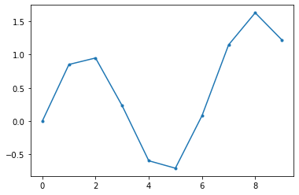

```python
plt.plot(X, T, '.-')
```

```python
n_inputs = X.shape[1]
n_outputs = T.shape[1]

nnet = NeuralNetwork(n_inputs, [3, 2], n_outputs)
nnet
```

```
NeuralNetwork (1, [3, 2], 1)
```

```python
nnet.n_inputs, nnet.n_hiddens_each_layer, nnet.n_outputs
```

```
(1, [3, 2], 1)
```

```python
nnet.rmse_trace
```

```
[]
```

```python
nnet.Ws
```

```
[array([[ 0.00494438,  0.00599123, -0.00101978],
        [-0.00496342, -0.00515224, -0.00488689]]),
 array([[-0.00407087,  0.0023341 ],
        [ 0.00334689,  0.00413369],
        [-0.00065255,  0.00275376],
        [ 0.00118871,  0.00390344]]),
 array([[0.],
        [0.],
        [0.]])]
```

```python
nnet.set_weights_for_testing()
```

```
Weights set for testing by calling set_weights_for_testing()
```

```python
nnet.Ws
```

```
[array([[-0.31 , -0.106,  0.098],
        [-0.298, -0.094,  0.11 ]]),
 array([[-0.21      , -0.00714286],
        [-0.20428571, -0.00142857],
        [-0.19857143,  0.00428571],
        [-0.19285714,  0.01      ]]),
 array([[0.],
        [0.],
        [0.]])]
```

```python
nnet.train(X, T, n_epochs=1, learning_rate=0.1)
```

```
NeuralNetwork (1, [3, 2], 1)
```

```python
nnet.Zs
```

```
[array([[-1.5666989 ],
        [-1.21854359],
        [-0.87038828],
        [-0.52223297],
        [-0.17407766],
        [ 0.17407766],
        [ 0.52223297],
        [ 0.87038828],
        [ 1.21854359],
        [ 1.5666989 ]]),
 array([[ 0.1556019 ,  0.04124628, -0.07420025],
        [ 0.05307607,  0.00854289, -0.0360242 ],
        [-0.05058109, -0.02417879,  0.00225729],
        [-0.15315983, -0.05684874,  0.04053216],
        [-0.25254081, -0.0893974 ,  0.07868844],
        [-0.34686464, -0.12175623,  0.11661556],
        [-0.43465797, -0.15385829,  0.15420558],
        [-0.51490065, -0.18563881,  0.19135444],
        [-0.58703239, -0.21703564,  0.22796304],
        [-0.65091011, -0.24798976,  0.26393827]]),
 array([[-0.2313994 , -0.00793021],
        [-0.21231228, -0.00754217],
        [-0.19285534, -0.00715153],
        [-0.17346796, -0.00676227],
        [-0.15458409, -0.00637825],
        [-0.13659418, -0.00600292],
        [-0.11981504, -0.00563919],
        [-0.10447207, -0.00528929],
        [-0.09069498, -0.00495472],
        [-0.07852506, -0.00463638]]),
 array([[0.],
        [0.],
        [0.],
        [0.],
        [0.],
        [0.],
        [0.],
        [0.],
        [0.],
        [0.]])]
```

```python
print(nnet)
```

```
NeuralNetwork (1, [3, 2], 1), trained for 1 epochs with a final RMSE of [0.7549690018121533]
```

```python
nnet.X_means, nnet.X_stds
```

```
(array([4.5]), array([2.87228132]))
```

```python
nnet.T_means, nnet.T_stds
```

```
(array([0.48052095]), array([0.754969]))
```

```python
[Z.shape for Z in nnet.Zs]
```

```
[(10, 1), (10, 3), (10, 2), (10, 1)]
```

```python
nnet.Ws
```

```
[array([[-0.31 , -0.106,  0.098],
        [-0.298, -0.094,  0.11 ]]),
 array([[-0.21      , -0.00714286],
        [-0.20428571, -0.00142857],
        [-0.19857143,  0.00428571],
        [-0.19285714,  0.01      ]]),
 array([[-6.66133815e-18],
        [ 1.72409702e-03],
        [ 3.91828943e-05]])]
```

```python
dir(nnet)
```

```
['T_means',
 'T_stds',
 'Ws',
 'X_means',
 'X_stds',
 'Zs',
 '__class__',
 '__delattr__',
 '__dict__',
 '__dir__',
 '__doc__',
 '__eq__',
 '__format__',
 '__ge__',
 '__getattribute__',
 '__gt__',
 '__hash__',
 '__init__',
 '__init_subclass__',
 '__le__',
 '__lt__',
 '__module__',
 '__ne__',
 '__new__',
 '__reduce__',
 '__reduce_ex__',
 '__repr__',
 '__setattr__',
 '__sizeof__',
 '__str__',
 '__subclasshook__',
 '__weakref__',
 '_add_ones',
 '_forward',
 '_generate_weights',
 '_gradients',
 'n_epochs',
 'n_hiddens_each_layer',
 'n_inputs',
 'n_outputs',
 'rho',
 'rmse_score',
 'rmse_trace',
 'set_weights_for_testing',
 'train',
 'use']
```

```python
def plot_data_and_model(nnet, X, T):
    plt.clf()
    plt.subplot(2, 1, 1)
    plt.plot(nnet.rmse_trace)
    plt.xlabel('Epoch')
    plt.ylabel('RMSE')

    plt.subplot(2, 1, 2)
    Y = nnet.use(X)

    plt.plot(X, Y, 'o-', label='Y')
    plt.plot(X, T, 'o', label='T', alpha=0.5)
    plt.xlabel('X')
    plt.ylabel('T or Y')
    plt.legend();
```

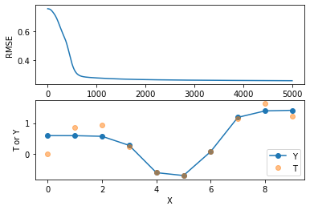

```python
X = np.arange(0, 10).reshape(-1, 1)
# X = np.arange(0, 0.5, 0.05).reshape(-1, 1)
T = np.sin(X) + 0.01 * (X ** 2)

n_inputs = X.shape[1]
n_outputs = T.shape[1]

nnet = NeuralNetwork(n_inputs, [10, 5], n_outputs)
nnet.set_weights_for_testing()

n_epochs = 5000
n_epochs_per_plot = 500


fig = plt.figure()
for reps in range(n_epochs // n_epochs_per_plot):
    plt.clf()
    nnet.train(X, T, n_epochs=n_epochs_per_plot, learning_rate=0.05)
    plot_data_and_model(nnet, X, T)
    ipd.clear_output(wait=True)
    ipd.display(fig)
    time.sleep(0.2)  # 0.2 seconds
ipd.clear_output(wait=True)
```

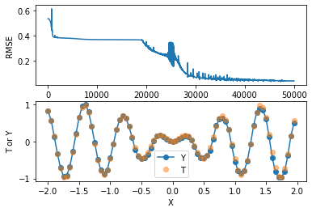

```python
X = np.arange(-2, 2, 0.05).reshape(-1, 1)
T = np.sin(X) * np.sin(X * 10)

n_inputs = X.shape[1]
n_outputs = T.shape[1]

nnet = NeuralNetwork(n_inputs, [50, 10, 5], n_outputs)
nnet.set_weights_for_testing()

n_epochs = 50000
n_epochs_per_plot = 500

fig = plt.figure()
for reps in range(n_epochs // n_epochs_per_plot):
    plt.clf()
    nnet.train(X, T, n_epochs=n_epochs_per_plot, learning_rate=0.1)
    plot_data_and_model(nnet, X, T)
    ipd.clear_output(wait=True)
    ipd.display(fig)
    # time.sleep(0.01)  # 0.01 seconds
ipd.clear_output(wait=True)
```

Your results will not be the same, but your code should complete and make plots somewhat similar to these.

## Application to Boston Housing Data

Download data from [Boston House Data at Kaggle](https://www.kaggle.com/fedesoriano/the-boston-houseprice-data). Read it into python using the `pandas.read_csv` function. Assign the first 13 columns as inputs to `X` and the final column as target values to `T`. Make sure `T` is two-dimensional.

Before training your neural networks, partition the data into training and testing partitions, as shown here.

```python
# Building 27 Data Structures
import itertools

def partition(X, T, train_fraction):
    """
    Creates train and test datasets.

    :param X: 2D numpy array.
              The input variables of the model.
    :param T: 2D numpy array
              The output variable of the model.
    :param X: float
              fraction of data in training set.
              The input variables of the model.

    return: Xtrain, Ttrain, Xtest, Ttest

    """
    n_samples = X.shape[0]
    rows = np.arange(n_samples)
    np.random.shuffle(rows)

    n_train = round(n_samples * train_fraction)
    Xtrain = X[rows[:n_train], :]
    Ttrain = T[rows[:n_train], :]
    Xtest = X[rows[n_train:], :]
    Ttest = T[rows[n_train:], :]

    return Xtrain, Ttrain, Xtest, Ttest

def make_param_grid(structure, rho, epoch):
    """
    Makes a gridspace with all possible combinations of input parameters.

    :param structure: list of int
                      Number of units in each hidden layers. Each element of the list represents one hidden layer.
    :param rho: float
                Learning rate of the model.
    :param epoch: int
                  Number of epoch to run the model.

    :return: A list of all parameter combinations.
    """
    param_combs = list(itertools.product(*[structure, rho, epoch]))
    return param_combs

def rmse(Y, T):
    """
    calculates rmse score
    """
    return np.sqrt(np.mean((Y-T)**2))

def configure_nnet_model(X, T, structures, rhos, epochs, train_test_ratio):
    """
    Runs the model for number of times of parameter combinations and saves model layout, train rmse, and test rmse.

    :param X: 2D numpy array.
              The input variables of the model.
    :param T: 2D numpy array
              The output variable of the model.
    :param structures: A nested list of int, such as [[50, 20], [30, 10]]
                       Number of units in each hidden layers. Each element of the list represents one hidden layer.
    :param rhos: list of float
                 Learning rate of the model.
    :param epochs: list of int
                   Number of epoch to run the model.
    :param train_test_ratio: float
                             ratio of dataset in training.

    :return: A dataframe with model layouts and respective train test rmse.
    """
    parameter_combinations = make_param_grid(structures, rhos, epochs)

    Xtrain, Ttrain, Xtest, Ttest = partition(X, T, train_test_ratio)

    n_inputs, n_outputs = Xtrain.shape[1], Ttrain.shape[1]

    result_dict = {'Structure': [], 'Epochs': [], 'Learning Rate': [], 'Train RMSE': [],
                   'Test RMSE': []}

    for params in parameter_combinations:
        hidden_layers, rho, epoch = params
        print(f'Training for {hidden_layers=}, {rho=}, {epoch=}')
        nn_model = NeuralNetwork(n_inputs, hidden_layers, n_outputs)
        nn_model.train(Xtrain, Ttrain, epoch, learning_rate=rho)

        # RMSE (No standardization is required)
        Ttrain_predicted = nn_model.use(Xtrain)
        rmse_train = rmse(Ttrain_predicted, Ttrain)

        Ttest_predicted = nn_model.use(Xtest)
        rmse_test = rmse(Ttest_predicted, Ttest)

        # appending results to the result dictionary
        result_dict['Structure'].append(hidden_layers)
        result_dict['Epochs'].append(epoch)
        result_dict['Learning Rate'].append(rho)
        result_dict['Train RMSE'].append(rmse_train)
        result_dict['Test RMSE'].append(rmse_test)

    result_df = pd.DataFrame(result_dict)
    result_df.sort_values(by=['Test RMSE'], axis=0, ascending=True, inplace=True)

    return result_df
```

```python
# Reading Boston Data
boston_df = pd.read_csv('boston.csv')
boston_df.columns
```

```
Index(['CRIM', 'ZN', 'INDUS', 'CHAS', 'NOX', 'RM', 'AGE', 'DIS', 'RAD', 'TAX',
       'PTRATIO', 'B', 'LSTAT', 'MEDV'],
      dtype='object')
```

```python
X_df = boston_df.iloc[:, :-1]
T_df = boston_df.iloc[:, -1:]
X_df.head()
```

|  | CRIM | ZN | INDUS | CHAS | NOX | RM | AGE | DIS | RAD | TAX | PTRATIO | B | LSTAT |
| --- | --- | --- | --- | --- | --- | --- | --- | --- | --- | --- | --- | --- | --- |
| 0 | 0.00632 | 18.0 | 2.31 | 0 | 0.538 | 6.575 | 65.2 | 4.0900 | 1 | 296.0 | 15.3 | 396.90 | 4.98 |
| 1 | 0.02731 | 0.0 | 7.07 | 0 | 0.469 | 6.421 | 78.9 | 4.9671 | 2 | 242.0 | 17.8 | 396.90 | 9.14 |
| 2 | 0.02729 | 0.0 | 7.07 | 0 | 0.469 | 7.185 | 61.1 | 4.9671 | 2 | 242.0 | 17.8 | 392.83 | 4.03 |
| 3 | 0.03237 | 0.0 | 2.18 | 0 | 0.458 | 6.998 | 45.8 | 6.0622 | 3 | 222.0 | 18.7 | 394.63 | 2.94 |
| 4 | 0.06905 | 0.0 | 2.18 | 0 | 0.458 | 7.147 | 54.2 | 6.0622 | 3 | 222.0 | 18.7 | 396.90 | 5.33 |

```python
T_df.head()
```

|  | MEDV |
| --- | --- |
| 0 | 24.0 |
| 1 | 21.6 |
| 2 | 34.7 |
| 3 | 33.4 |
| 4 | 36.2 |

```python
X = X_df.to_numpy()
T = T_df.to_numpy()
```

```python
# Train Test partition using partition() function
Xtrain, Ttrain, Xtest, Ttest = partition(X, T, train_fraction=0.7)
np.hstack((Xtest, Ttest))
```

```
array([[1.50380e-01, 0.00000e+00, 2.56500e+01, ..., 3.70310e+02,
        2.54100e+01, 1.73000e+01],
       [4.42228e+00, 0.00000e+00, 1.81000e+01, ..., 3.31290e+02,
        2.13200e+01, 1.91000e+01],
       [4.75470e-01, 0.00000e+00, 9.90000e+00, ..., 3.96230e+02,
        1.27300e+01, 2.10000e+01],
       ...,
       [1.28160e-01, 1.25000e+01, 6.07000e+00, ..., 3.96900e+02,
        8.79000e+00, 2.09000e+01],
       [5.09017e+00, 0.00000e+00, 1.81000e+01, ..., 3.85090e+02,
        1.72700e+01, 1.61000e+01],
       [1.44383e+01, 0.00000e+00, 1.81000e+01, ..., 1.79360e+02,
        1.97800e+01, 2.75000e+01]])
```

Write and run code using your `NeuralNetwork` class to model the Boston housing data. Experiment with a variety of neural network structures (numbers of hidden layer and units) including no hidden layers, learning rates, and numbers of epochs. Show results for at least three different **network structures, learning rates, and numbers of epochs** for a total of at least 27 results. Show your results in a `pandas` DataFrame with columns `('Structure', 'Epochs', 'Learning Rate', 'Train RMSE', 'Test RMSE')`.

Try to find good values for the RMSE on testing data. Discuss your results, including how good you think the RMSE values are by considering the range of house values given in the data.

```python
# Searching for best model layout for Boston data
nnet_structure = [[30, 20, 10, 5], [10, 5], []]
nnet_rho = [0.001, 0.005, 0.01]
nnet_epoch = [2000, 5000, 10000]

results = configure_nnet_model(X, T, nnet_structure, nnet_rho, nnet_epoch, train_test_ratio=0.7)
results
```

```
Training for hidden_layers=[30, 20, 10, 5], rho=0.001, epoch=2000
Training for hidden_layers=[30, 20, 10, 5], rho=0.001, epoch=5000
Training for hidden_layers=[30, 20, 10, 5], rho=0.001, epoch=10000
Training for hidden_layers=[30, 20, 10, 5], rho=0.005, epoch=2000
Training for hidden_layers=[30, 20, 10, 5], rho=0.005, epoch=5000
Training for hidden_layers=[30, 20, 10, 5], rho=0.005, epoch=10000
Training for hidden_layers=[30, 20, 10, 5], rho=0.01, epoch=2000
Training for hidden_layers=[30, 20, 10, 5], rho=0.01, epoch=5000
Training for hidden_layers=[30, 20, 10, 5], rho=0.01, epoch=10000
Training for hidden_layers=[10, 5], rho=0.001, epoch=2000
Training for hidden_layers=[10, 5], rho=0.001, epoch=5000
Training for hidden_layers=[10, 5], rho=0.001, epoch=10000
Training for hidden_layers=[10, 5], rho=0.005, epoch=2000
Training for hidden_layers=[10, 5], rho=0.005, epoch=5000
Training for hidden_layers=[10, 5], rho=0.005, epoch=10000
Training for hidden_layers=[10, 5], rho=0.01, epoch=2000
Training for hidden_layers=[10, 5], rho=0.01, epoch=5000
Training for hidden_layers=[10, 5], rho=0.01, epoch=10000
Training for hidden_layers=[], rho=0.001, epoch=2000
Training for hidden_layers=[], rho=0.001, epoch=5000
Training for hidden_layers=[], rho=0.001, epoch=10000
Training for hidden_layers=[], rho=0.005, epoch=2000
Training for hidden_layers=[], rho=0.005, epoch=5000
Training for hidden_layers=[], rho=0.005, epoch=10000
Training for hidden_layers=[], rho=0.01, epoch=2000
Training for hidden_layers=[], rho=0.01, epoch=5000
Training for hidden_layers=[], rho=0.01, epoch=10000
```

|  | Structure | Epochs | Learning Rate | Train RMSE | Test RMSE |
| --- | --- | --- | --- | --- | --- |
| 26 | [] | 10000 | 0.010 | 4.708426 | 4.716895 |
| 25 | [] | 5000 | 0.010 | 4.708528 | 4.720092 |
| 23 | [] | 10000 | 0.005 | 4.708528 | 4.720094 |
| 22 | [] | 5000 | 0.005 | 4.711002 | 4.736562 |
| 24 | [] | 2000 | 0.010 | 4.713414 | 4.746626 |
| 21 | [] | 2000 | 0.005 | 4.730785 | 4.796795 |
| 20 | [] | 10000 | 0.001 | 4.730795 | 4.796818 |
| 19 | [] | 5000 | 0.001 | 4.772223 | 4.877371 |
| 18 | [] | 2000 | 0.001 | 4.881085 | 5.026268 |
| 17 | [10, 5] | 10000 | 0.010 | 9.264352 | 9.008369 |
| 16 | [10, 5] | 5000 | 0.010 | 9.264352 | 9.008369 |
| 14 | [10, 5] | 10000 | 0.005 | 9.264352 | 9.008370 |
| 13 | [10, 5] | 5000 | 0.005 | 9.264353 | 9.008371 |
| 11 | [10, 5] | 10000 | 0.001 | 9.264354 | 9.008371 |
| 15 | [10, 5] | 2000 | 0.010 | 9.264354 | 9.008371 |
| 12 | [10, 5] | 2000 | 0.005 | 9.264354 | 9.008371 |
| 10 | [10, 5] | 5000 | 0.001 | 9.264354 | 9.008371 |
| 9 | [10, 5] | 2000 | 0.001 | 9.264354 | 9.008371 |
| 8 | [30, 20, 10, 5] | 10000 | 0.010 | 9.264354 | 9.008371 |
| 3 | [30, 20, 10, 5] | 2000 | 0.005 | 9.264354 | 9.008371 |
| 1 | [30, 20, 10, 5] | 5000 | 0.001 | 9.264354 | 9.008371 |
| 2 | [30, 20, 10, 5] | 10000 | 0.001 | 9.264354 | 9.008371 |
| 7 | [30, 20, 10, 5] | 5000 | 0.010 | 9.264354 | 9.008371 |
| 5 | [30, 20, 10, 5] | 10000 | 0.005 | 9.264354 | 9.008371 |
| 4 | [30, 20, 10, 5] | 5000 | 0.005 | 9.264354 | 9.008371 |
| 0 | [30, 20, 10, 5] | 2000 | 0.001 | 9.264354 | 9.008371 |
| 6 | [30, 20, 10, 5] | 2000 | 0.010 | 9.264354 | 9.008371 |

### Discussion

**Three** types of model structures were tested for the designed Neural Network class using the **Boston** dataset.

Surprisingly, **No hidden layers** NN models performs the best in terms of RMSE values. Test rmse is higher than train rmse, which means there is no overfitting. The best possible reason for such good performance can be -the variables in boston dataset are very linearly connected to the output variable 'median value'. So, even model with no hidden layers work that well. With this fewer training sample and 13 number of variables, a model with no hidden layer might be the best model.

# Grading

Your notebook will be run and graded automatically. Test this grading process by first downloading A2grader.tar and extract `A2grader.py` from it. Run the code in the following cell to demonstrate an example grading session. The remaining 20 points will be based on your discussion of this assignment.

A different, but similar, grading script will be used to grade your checked-in notebook. It will include additional tests. You should design and perform additional tests on all of your functions to be sure they run correctly before checking in your notebook.

For the grading script to run correctly, you must first name this notebook as `Lastname-A2.ipynb` with `Lastname` being your last name, and then save this notebook.

```python
%run -i A2grader.py
```

```
======================= Code Execution =======================

Extracting python code from notebook named 'A2 NeuralNetwork Class.ipynb' and storing in notebookcode.py
Removing all statements that are not function or class defs or import statements.

Testing

    n_inputs = 3
    n_hiddens = [2, 1]
    n_outputs = 2
    n_samples = 5

    X = np.arange(n_samples * n_inputs).reshape(n_samples, n_inputs) * 0.1
    T = np.hstack((X, X*2))

    nnet = NeuralNetwork(n_inputs, n_hiddens, n_outputs)
    nnet.set_weights_for_testing()

    # Set standardization variables so use() will run
    nnet.X_means = 0
    nnet.X_stds = 1
    nnet.T_means = 0
    nnet.T_stds = 1

    Y = nnet.use(X)

Weights set for testing by calling set_weights_for_testing()

--- 20/20 points. Returned correct value.

Testing

    n_inputs = 3
    n_hiddens = []   # NO HIDDEN LAYERS.  SO THE NEURAL NET IS JUST A LINEAR MODEL.
    n_samples = 5

    X = np.arange(n_samples * n_inputs).reshape(n_samples, n_inputs) * 0.1
    T = np.hstack((X, X*2))
    n_outputs = T.shape[1]

```

[output cut: 44 more lines]

```
======================================================================
F:\PhD_Course_materials_documents\Course_Materials_Fall_2022\CS_545_Machine_Learning\Assignments\Assignment_2 Experiments and Discussion Grade is __ / 20
======================================================================

======================================================================
F:\PhD_Course_materials_documents\Course_Materials_Fall_2022\CS_545_Machine_Learning\Assignments\Assignment_2 FINAL GRADE is  ___ / 100
======================================================================

Extra Credit:

Apply your functions to a data set from the UCI Machine Learning Repository.
Explain your steps and results in markdown cells.


F:\PhD_Course_materials_documents\Course_Materials_Fall_2022\CS_545_Machine_Learning\Assignments\Assignment_2 EXTRA CREDIT is 0 / 1
```

# Extra Credit

Apply your multilayer neural network code to a regression problem using data that you choose from the [UCI Machine Learning Repository](http://archive.ics.uci.edu/ml/datasets.php). Pick a dataset that is listed as being appropriate for regression.